# California Housing Price Prediction: Moving Beyond Linearity

Nonparametric Regression Project

Alpha Numeric Group 1

2026-05-09

# 1 Introduction & Objectives

This project applies the nonparametric and semi-parametric regression techniques to the California Housing dataset. The central thesis is that the relationship between housing price and its predictors is **inherently nonlinear and spatially interactive**, a claim we test rigorously by comparing a full ladder of model families.

**Research Questions**

1. Can ensemble nonlinear models (Random Forest, XGBoost, Neural Network) predict house prices more accurately than classical approaches? What are the most important nonlinear interactions between location and income?
2. Which model family — **GNPR** (GAM, Kernel/Local Regression, Splines, Step Functions, Polynomial) vs. **Parametric** (Linear, Ridge) vs. **Machine Learning** (RF, XGBoost, NN) — provides the best predictive accuracy?

**Model Ladder**

| # | Model | Family |
| --- | --- | --- |
| 1 | Multiple Linear Regression | Parametric (baseline) |
| 2 | Polynomial Regression (degree 3) | GNPR |
| 3 | Step Function Regression | GNPR |
| 4 | Regression Splines (B-splines, Natural Splines) | GNPR |
| 5 | Smoothing Spline (via GAM `s()`) | GNPR |
| 6 | Local Regression (LOESS) | GNPR |
| 7 | Generalized Additive Model (GAM + tensor interactions) | GNPR |
| 8 | Random Forest | ML Ensemble |
| 9 | XGBoost | ML Ensemble |
| 10 | Neural Network (MLP) | ML / Deep Learning |

# 2 Package Installation & Loading

```r
# Install any missing packages
required_pkgs <- c(
  "tidyverse", "caret", "randomForest", "xgboost",
  "mgcv", "splines", "np", "corrplot", "gridExtra",
  "Metrics", "neuralnet", "ggplot2", "viridis", "scales",
  "pdp", "vip", "spdep", "sf", "kableExtra", "GGally",
  "patchwork", "ggrepel"
)

new_pkgs <- required_pkgs[!required_pkgs %in% rownames(installed.packages())]
if (length(new_pkgs) > 0) {
  install.packages(new_pkgs, dependencies = TRUE, repos = "https://cloud.r-project.org")
}

# Load libraries
suppressPackageStartupMessages({
  library(tidyverse)
  library(caret)
  library(randomForest)
  library(xgboost)
  library(mgcv)          # GAM, smoothing splines
  library(splines)       # bs(), ns()
  library(np)            # Kernel / local regression
  library(corrplot)
  library(gridExtra)
  library(Metrics)       # rmse(), mae()
  library(neuralnet)
  library(ggplot2)
  library(viridis)
  library(scales)
  library(pdp)           # Partial Dependence Plots
  library(vip)           # Variable Importance Plots
  library(spdep)         # Moran's I
  library(sf)
  library(kableExtra)
  library(GGally)
  library(patchwork)
  library(ggrepel)
})

# Global ggplot theme
theme_set(theme_minimal(base_size = 12) +
            theme(plot.title = element_text(face = "bold", size = 13),
                  plot.subtitle = element_text(color = "grey40")))
```

# 3 Data Loading & Initial Inspection

```r
# Load dataset (no header row)
data <- read.csv("D:/Module 3/Linear Models/California Housing Price project/Github/cal_housing.data", header = FALSE)


colnames(data) <- c("longitude", "latitude", "housing_median_age",
  "total_rooms", "total_bedrooms", "population",
  "households", "median_income", "median_house_value"
)


cat("Dimensions       :", dim(data), "\n")
```

```
Dimensions       : 20640 9
```

```r
cat("Missing values   :", sum(is.na(data)), "\n")
```

```
Missing values   : 0
```

```r
head(data, 6)
```

|  | longitude | latitude | housing_median_age | total_rooms | total_bedrooms | population | households | median_income | median_house_value |
| --- | --- | --- | --- | --- | --- | --- | --- | --- | --- |
| 1 | -122.23 | 37.88 | 41 | 880 | 129 | 322 | 126 | 8.3252 | 452600 |
| 2 | -122.22 | 37.86 | 21 | 7099 | 1106 | 2401 | 1138 | 8.3014 | 358500 |
| 3 | -122.24 | 37.85 | 52 | 1467 | 190 | 496 | 177 | 7.2574 | 352100 |
| 4 | -122.25 | 37.85 | 52 | 1274 | 235 | 558 | 219 | 5.6431 | 341300 |
| 5 | -122.25 | 37.85 | 52 | 1627 | 280 | 565 | 259 | 3.8462 | 342200 |
| 6 | -122.25 | 37.85 | 52 | 919 | 213 | 413 | 193 | 4.0368 | 269700 |

```r
summary(data)
```

```
   longitude         latitude     housing_median_age  total_rooms    total_bedrooms     population
 Min.   :-124.3   Min.   :32.54   Min.   : 1.00      Min.   :    2   Min.   :   1.0   Min.   :    3
 1st Qu.:-121.8   1st Qu.:33.93   1st Qu.:18.00      1st Qu.: 1448   1st Qu.: 295.0   1st Qu.:  787
 Median :-118.5   Median :34.26   Median :29.00      Median : 2127   Median : 435.0   Median : 1166
 Mean   :-119.6   Mean   :35.63   Mean   :28.64      Mean   : 2636   Mean   : 537.9   Mean   : 1425
 3rd Qu.:-118.0   3rd Qu.:37.71   3rd Qu.:37.00      3rd Qu.: 3148   3rd Qu.: 647.0   3rd Qu.: 1725
 Max.   :-114.3   Max.   :41.95   Max.   :52.00      Max.   :39320   Max.   :6445.0   Max.   :35682
   households     median_income     median_house_value
 Min.   :   1.0   Min.   : 0.4999   Min.   : 14999
 1st Qu.: 280.0   1st Qu.: 2.5634   1st Qu.:119600
 Median : 409.0   Median : 3.5348   Median :179700
 Mean   : 499.5   Mean   : 3.8707   Mean   :206856
 3rd Qu.: 605.0   3rd Qu.: 4.7432   3rd Qu.:264725
 Max.   :6082.0   Max.   :15.0001   Max.   :500001
```

# 4 Exploratory Data Analysis

## 4.1 Distributions of All Variables

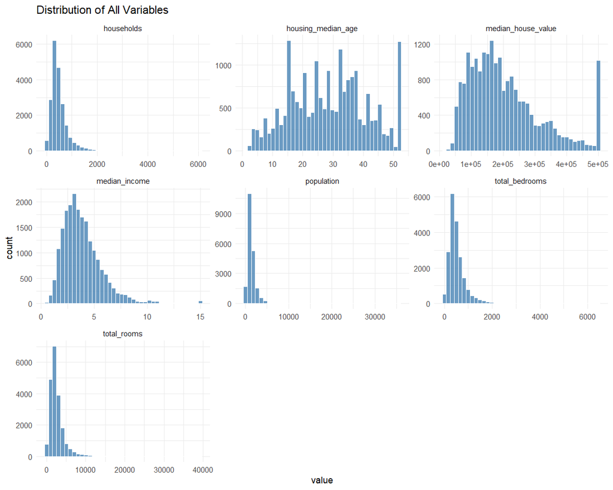

```r
data_long <- data %>%
  select(-c(longitude,latitude)) %>%
  pivot_longer(everything(), names_to = "variable", values_to = "value")

ggplot(data_long, aes(x = value)) +
  geom_histogram(bins = 40, fill = "steelblue", color = "white", alpha = 0.8) +
  #geom_vline(xintercept = median(x)) +
  facet_wrap(~variable, scales = "free") +
  theme_minimal() +
  labs(title = "Distribution of All Variables")
```

- The numeric features are skewed to the right apart from housing_median_age which is bi-modal.

## 4.2 Correlation Structure

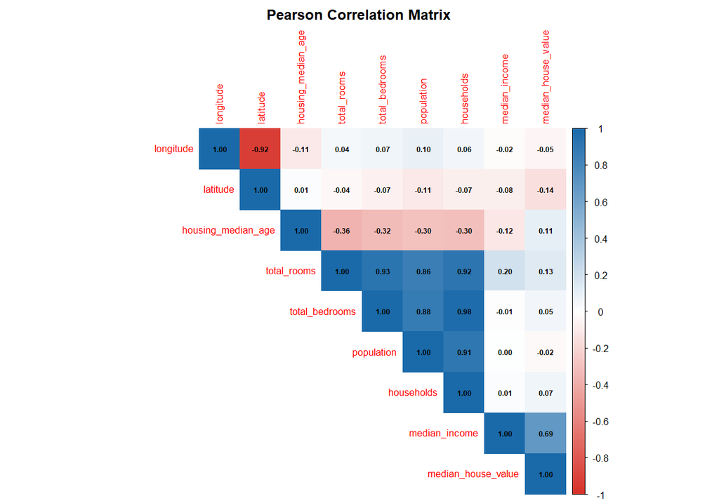

```r
cor_matrix <- cor(data, use = "complete.obs")
corrplot(
  cor_matrix,
  method      = "color",
  type        = "upper",
  tl.cex      = 0.85,
  addCoef.col = "black",
  number.cex  = 0.60,
  col         = colorRampPalette(c("#d73027","white","#1a6aaa"))(200),
  title       = "Pearson Correlation Matrix",
  mar         = c(0, 0, 2, 0)
)
```

- There is a very high correlation between total bedrooms, population, households and total rooms. Median income has a high correlation with median house value.

## 4.3 Geographic Distribution

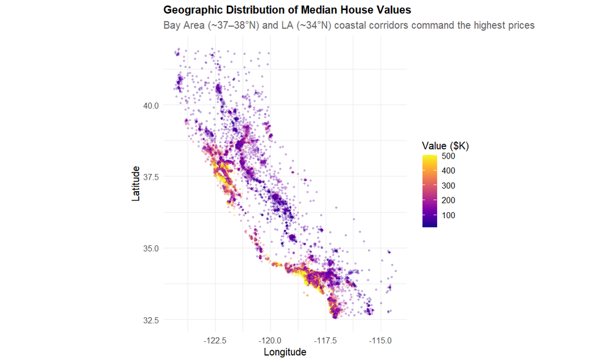

```r
ggplot(data, aes(x = longitude, y = latitude, color = median_house_value / 1e3)) +
  geom_point(alpha = 0.25, size = 0.7) +
  scale_color_viridis(name = "Value ($K)", option = "C", labels = comma) +
  coord_fixed(ratio = 1.3) +
  labs(
    title    = "Geographic Distribution of Median House Values",
    subtitle = "Bay Area (~37–38°N) and LA (~34°N) coastal corridors command the highest prices",
    x = "Longitude", y = "Latitude"
  )
```

-Expensive neighborhoods tend to be geographically grouped together. Additionally, expensive neighborhoods are on the western part of California near the ocean while cheaper houses are located towards the inland side.Due to urban planning, house prices seems to be regulated to a maximum of $500001 and a minimum of approximately $15000.

## 4.4 Spatial Autocorrelation — Moran’s I Test

```r
# Build spatial object and k-NN weights (k = 5)
spatial_obj <- st_as_sf(data, coords = c("longitude", "latitude"), crs = 4326)
coords      <- st_coordinates(spatial_obj)
knn5        <- knn2nb(knearneigh(coords, k = 5))
lw          <- nb2listw(knn5, style = "W")

# Moran's I — median income
moran_income <- moran.test(data$median_income, lw)
cat("Moran's I (median_income)      :", round(moran_income$estimate["Moran I statistic"], 4), "\n")
```

```
Moran's I (median_income)      : 0.5963
```

```r
cat("p-value                        :", format(moran_income$p.value, scientific = TRUE), "\n")
```

```
p-value                        : 0e+00
```

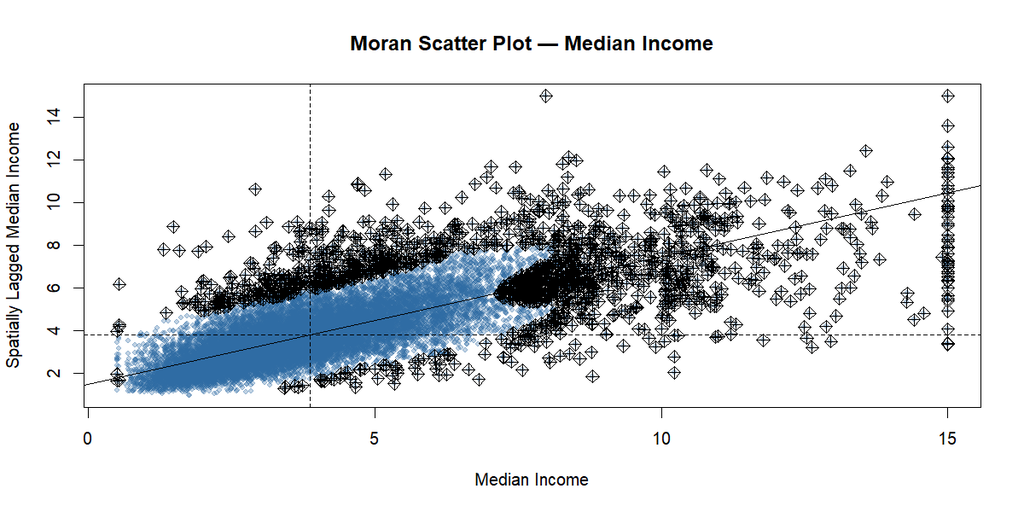

```r
moran.plot(
  data$median_income, lw,
  labels = FALSE,
  main   = "Moran Scatter Plot — Median Income",
  xlab   = "Median Income", ylab = "Spatially Lagged Median Income",
  pch    = 20, col = rgb(0.18, 0.42, 0.64, 0.3)
)
```

```r
# Moran's I — house value
moran_value <- moran.test(data$median_house_value, lw)
cat("Moran's I (median_house_value) :", round(moran_value$estimate["Moran I statistic"], 4), "\n")
```

```
Moran's I (median_house_value) : 0.8137
```

```r
cat("p-value                        :", format(moran_value$p.value, scientific = TRUE), "\n")
```

```
p-value                        : 0e+00
```

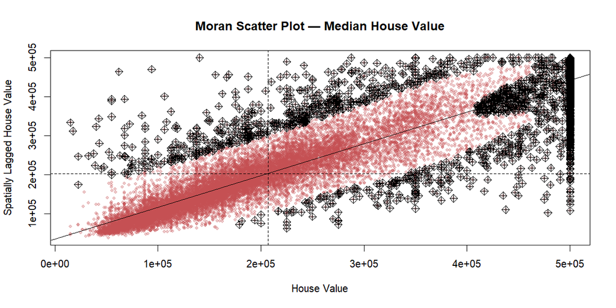

```r
moran.plot(
  data$median_house_value, lw,
  labels = FALSE,
  main   = "Moran Scatter Plot — Median House Value",
  xlab   = "House Value", ylab = "Spatially Lagged House Value",
  pch    = 20, col = rgb(0.77, 0.31, 0.32, 0.3)
)
```

- Both Moran’s I statistics are **highly significant** (p < 2.2e-16), confirming strong positive spatial autocorrelation in both income and house values. Nearby block-groups tend to have similar values, underpinning why location features (latitude, longitude) are critical predictors.

## 4.5 Nonlinearity: Income vs. House Value

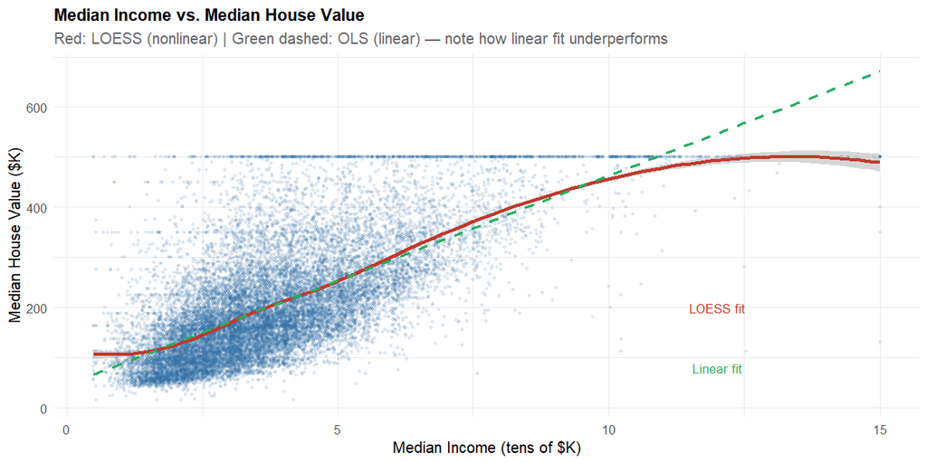

```r
ggplot(data, aes(x = median_income, y = median_house_value / 1e3)) +
  geom_point(alpha = 0.12, color = "#2e6da4", size = 0.7) +
  geom_smooth(method = "loess", color = "#c0392b", linewidth = 1.2, se = TRUE) +
  geom_smooth(method = "lm",    color = "#27ae60", linewidth = 1,   se = FALSE,
              linetype = "dashed") +
  labs(
    title    = "Median Income vs. Median House Value",
    subtitle = "Red: LOESS (nonlinear) | Green dashed: OLS (linear) — note how linear fit underperforms",
    x = "Median Income (tens of $K)", y = "Median House Value ($K)"
  ) +
  annotate("text", x = 12, y = 80, label = "Linear fit", color = "#27ae60", size = 3.5) +
  annotate("text", x = 12, y = 200, label = "LOESS fit", color = "#c0392b", size = 3.5)
```

# 5 Feature Engineering & Preprocessing

```r
# ── Derived features ───────────────────────────────────────────────────────────
data_clean <- data %>%
  mutate(
    rooms_per_household      = total_rooms    / households,
    bedrooms_per_room        = total_bedrooms / total_rooms,
    population_per_household = population     / households
  ) %>%
  # Remove raw aggregate columns that are replaced by per-unit ratios
  # (kept for spatial models but removed from feature set to reduce multicollinearity)
  select(everything()) %>%  # ensure no old columns
  select(longitude, latitude, housing_median_age,
         total_rooms, total_bedrooms, population, households,
         median_income, rooms_per_household, bedrooms_per_room,
         population_per_household, median_house_value)

cat("Feature-engineered dataset dimensions:", dim(data_clean), "\n")
```

```
Feature-engineered dataset dimensions: 20640 12
```

```r
glimpse(data_clean)
```

```
Rows: 20,640
Columns: 12
$ longitude                <dbl> -122.23, -122.22, -122.24, -122.25, -122.25, -122.25, -122.25, -122.25, -122.26, -1…
$ latitude                 <dbl> 37.88, 37.86, 37.85, 37.85, 37.85, 37.85, 37.84, 37.84, 37.84, 37.84, 37.85, 37.85,…
$ housing_median_age       <dbl> 41, 21, 52, 52, 52, 52, 52, 52, 42, 52, 52, 52, 52, 52, 52, 50, 52, 52, 50, 52, 40,…
$ total_rooms              <dbl> 880, 7099, 1467, 1274, 1627, 919, 2535, 3104, 2555, 3549, 2202, 3503, 2491, 696, 26…
$ total_bedrooms           <dbl> 129, 1106, 190, 235, 280, 213, 489, 687, 665, 707, 434, 752, 474, 191, 626, 283, 34…
$ population               <dbl> 322, 2401, 496, 558, 565, 413, 1094, 1157, 1206, 1551, 910, 1504, 1098, 345, 1212, …
$ households               <dbl> 126, 1138, 177, 219, 259, 193, 514, 647, 595, 714, 402, 734, 468, 174, 620, 264, 33…
$ median_income            <dbl> 8.3252, 8.3014, 7.2574, 5.6431, 3.8462, 4.0368, 3.6591, 3.1200, 2.0804, 3.6912, 3.2…
$ rooms_per_household      <dbl> 6.984127, 6.238137, 8.288136, 5.817352, 6.281853, 4.761658, 4.931907, 4.797527, 4.2…
$ bedrooms_per_room        <dbl> 0.1465909, 0.1557966, 0.1295160, 0.1844584, 0.1720959, 0.2317737, 0.1928994, 0.2213…
$ population_per_household <dbl> 2.555556, 2.109842, 2.802260, 2.547945, 2.181467, 2.139896, 2.128405, 1.788253, 2.0…
$ median_house_value       <dbl> 452600, 358500, 352100, 341300, 342200, 269700, 299200, 241400, 226700, 261100, 281…
```

```r
set.seed(42)

# Feature names used across all models (excludes lat/lon for scaled versions)
features_no_geo <- c(
  "housing_median_age", "median_income",
  "rooms_per_household", "bedrooms_per_room", "population_per_household"
)

features_all <- c("longitude", "latitude", features_no_geo)

# Scale ALL numeric features (for parametric & NN models)
preproc_all <- preProcess(
  data_clean[, features_all],
  method = c("center", "scale")
)
data_scaled <- predict(preproc_all, data_clean[, features_all])
data_scaled$median_house_value <- data_clean$median_house_value

# Train / test split (80 / 20)
train_idx <- createDataPartition(data_scaled$median_house_value, p = 0.8, list = FALSE)

train_sc  <- data_scaled[ train_idx, ]
test_sc   <- data_scaled[-train_idx, ]

train_raw <- data_clean[ train_idx, ]
test_raw  <- data_clean[-train_idx, ]

X_train <- train_sc[, features_all]
y_train <- train_sc$median_house_value
X_test  <- test_sc[,  features_all]
y_test  <- test_sc$median_house_value

cat("Training set size :", nrow(train_sc), "\n")
```

```
Training set size : 16513
```

```r
cat("Test set size     :", nrow(test_sc),  "\n")
```

```
Test set size     : 4127
```

```r
# Unified metrics helper
calc_metrics <- function(actual, predicted, model_name) {
  rmse_val <- rmse(actual, predicted)
  mae_val  <- mae(actual, predicted)
  r2_val   <- cor(actual, predicted)^2
  tibble(
    Model = model_name,
    RMSE  = round(rmse_val, 2),
    MAE   = round(mae_val,  2),
    R2    = round(r2_val,   4)
  )
}

# Storage for predictions and metrics
all_metrics <- list()
all_preds   <- list(Actual = y_test)
```

# 6 Model 1 — Multiple Linear Regression (Baseline)

**Theoretical basis:** The standard parametric model assumes:

$$y_i = \beta_0 + \beta_1 x_{i1} + \cdots
+ \beta_p x_{ip} + \varepsilon_i$$

This imposes linearity and additivity, a restriction we will systematically relax in subsequent models.

```r
lm_formula <- as.formula(
  paste("median_house_value ~", paste(features_all, collapse = " + "))
)

lm_model <- lm(lm_formula, data = train_sc)
summary(lm_model)
```

```
Call:
lm(formula = lm_formula, data = train_sc)

Residuals:
    Min      1Q  Median      3Q     Max
-595183  -45123  -12626   30988  426459

Coefficients:
                         Estimate Std. Error t value Pr(>|t|)
(Intercept)              206722.5      555.2 372.323  < 2e-16 ***
longitude                -85240.1     1660.5 -51.333  < 2e-16 ***
latitude                 -87735.6     1689.8 -51.921  < 2e-16 ***
housing_median_age        12391.0      587.5  21.092  < 2e-16 ***
median_income             83341.4      789.9 105.511  < 2e-16 ***
rooms_per_household        9510.9      675.6  14.078  < 2e-16 ***
bedrooms_per_room         21806.6      770.6  28.300  < 2e-16 ***
population_per_household  -3692.7      497.8  -7.418 1.24e-13 ***
---
Signif. codes:  0 ‘***’ 0.001 ‘**’ 0.01 ‘*’ 0.05 ‘.’ 0.1 ‘ ’ 1

Residual standard error: 71350 on 16505 degrees of freedom
Multiple R-squared:  0.6146,    Adjusted R-squared:  0.6144
F-statistic:  3760 on 7 and 16505 DF,  p-value: < 2.2e-16
```

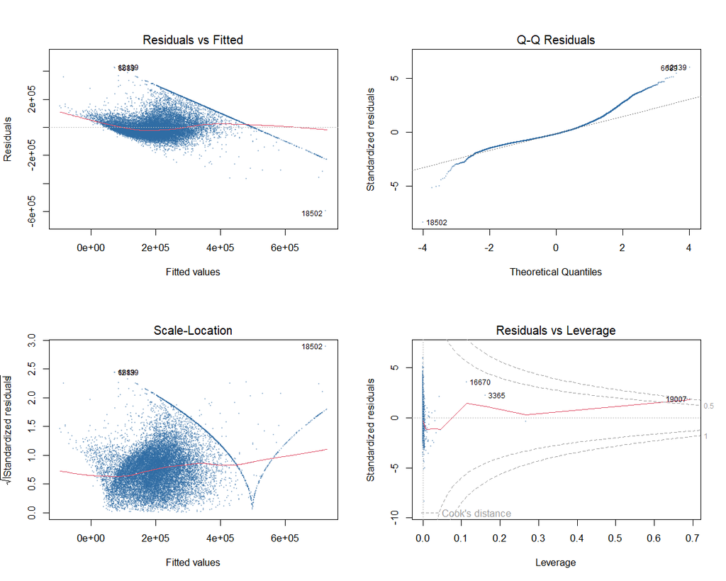

```r
par(mfrow = c(2, 2))
plot(lm_model, pch = 20, cex = 0.4, col = rgb(0.18, 0.42, 0.64, 0.3))
par(mfrow = c(1, 1))
```

```r
lm_pred <- predict(lm_model, newdata = test_sc)

all_preds[["LinearRegression"]] <- lm_pred
all_metrics[["LinearRegression"]] <- calc_metrics(y_test, lm_pred, "1. Linear Regression")

cat("Linear Regression — RMSE:", all_metrics$LinearRegression$RMSE,
    "| R²:", all_metrics$LinearRegression$R2, "\n")
```

```
Linear Regression — RMSE: 73005.27 | R²: 0.6134
```

# 7 Model 2 — Polynomial Regression (Degree 3)

**Theoretical basis** Polynomial regression extends the linear model by raising predictors to powers:

$$y_i = \beta_0 + \beta_1 x_i + \beta_2
x_i^2 + \cdots + \beta_d x_i^d + \varepsilon_i$$

```r
poly_model <- lm(
  median_house_value ~
    poly(median_income, 3, raw = FALSE) +   # orthogonal cubic poly
    poly(latitude,      3, raw = FALSE) +
    poly(longitude,     3, raw = FALSE) +
    poly(housing_median_age, 2, raw = FALSE) +
    rooms_per_household + bedrooms_per_room +
    population_per_household,
  data = train_sc
)

summary(poly_model)
```

```
Call:
lm(formula = median_house_value ~ poly(median_income, 3, raw = FALSE) +
    poly(latitude, 3, raw = FALSE) + poly(longitude, 3, raw = FALSE) +
    poly(housing_median_age, 2, raw = FALSE) + rooms_per_household +
    bedrooms_per_room + population_per_household, data = train_sc)

Residuals:
    Min      1Q  Median      3Q     Max
-406781  -43832  -10858   29777  443261

Coefficients:
                                            Estimate Std. Error t value Pr(>|t|)
(Intercept)                                2.065e+05  5.400e+02 382.452  < 2e-16 ***
poly(median_income, 3, raw = FALSE)1       1.096e+07  1.021e+05 107.324  < 2e-16 ***
poly(median_income, 3, raw = FALSE)2      -1.468e+06  7.497e+04 -19.583  < 2e-16 ***
poly(median_income, 3, raw = FALSE)3      -1.201e+06  6.981e+04 -17.207  < 2e-16 ***
poly(latitude, 3, raw = FALSE)1           -1.228e+07  2.566e+05 -47.868  < 2e-16 ***
poly(latitude, 3, raw = FALSE)2            1.153e+06  9.542e+04  12.089  < 2e-16 ***
poly(latitude, 3, raw = FALSE)3            7.764e+05  8.433e+04   9.207  < 2e-16 ***
poly(longitude, 3, raw = FALSE)1          -1.205e+07  2.540e+05 -47.454  < 2e-16 ***
poly(longitude, 3, raw = FALSE)2          -4.502e+05  8.390e+04  -5.367 8.13e-08 ***
poly(longitude, 3, raw = FALSE)3           7.077e+05  9.063e+04   7.809 6.12e-15 ***
poly(housing_median_age, 2, raw = FALSE)1  1.835e+06  7.465e+04  24.581  < 2e-16 ***
poly(housing_median_age, 2, raw = FALSE)2  5.792e+05  7.037e+04   8.230  < 2e-16 ***
rooms_per_household                        9.466e+03  6.588e+02  14.368  < 2e-16 ***
bedrooms_per_room                          2.501e+04  8.004e+02  31.249  < 2e-16 ***
population_per_household                  -3.904e+03  4.843e+02  -8.063 7.95e-16 ***
---
Signif. codes:  0 ‘***’ 0.001 ‘**’ 0.01 ‘*’ 0.05 ‘.’ 0.1 ‘ ’ 1

Residual standard error: 69390 on 16498 degrees of freedom
Multiple R-squared:  0.6356,    Adjusted R-squared:  0.6353
F-statistic:  2055 on 14 and 16498 DF,  p-value: < 2.2e-16
```

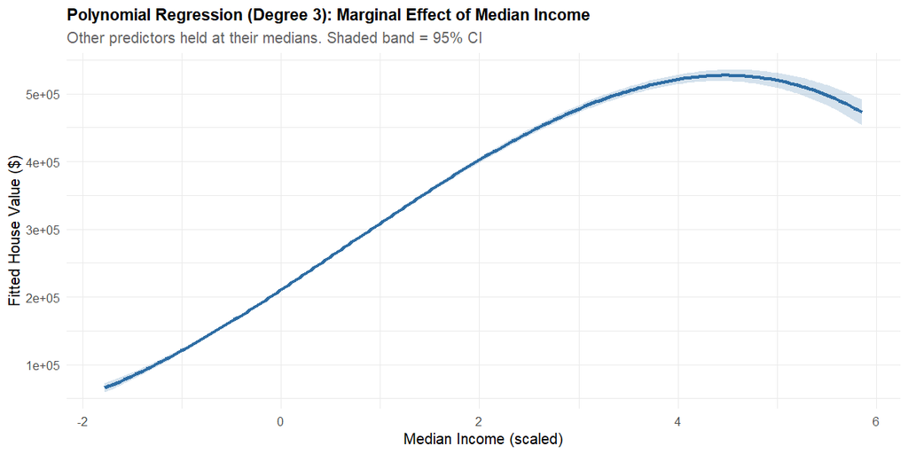

```r
# Visualise cubic polynomial fit for median_income (holding other vars at median)
income_grid <- data.frame(
  median_income            = seq(min(train_sc$median_income), max(train_sc$median_income), length = 200),
  latitude                 = median(train_sc$latitude),
  longitude                = median(train_sc$longitude),
  housing_median_age       = median(train_sc$housing_median_age),
  rooms_per_household      = median(train_sc$rooms_per_household),
  bedrooms_per_room        = median(train_sc$bedrooms_per_room),
  population_per_household = median(train_sc$population_per_household)
)

income_pred <- predict(poly_model, newdata = income_grid, interval = "confidence")
income_grid$fit  <- income_pred[, "fit"]
income_grid$lwr  <- income_pred[, "lwr"]
income_grid$upr  <- income_pred[, "upr"]

# Back-transform income from scaled to original for labelling
income_orig <- income_grid$median_income *
  attr(preproc_all$mean, "scaled:scale")["median_income"] +
  preproc_all$mean["median_income"]

ggplot(income_grid, aes(x = income_grid$median_income)) +
  geom_ribbon(aes(ymin = lwr, ymax = upr), fill = "#2e6da4", alpha = 0.2) +
  geom_line(aes(y = fit), color = "#2e6da4", linewidth = 1.2) +
  labs(
    title    = "Polynomial Regression (Degree 3): Marginal Effect of Median Income",
    subtitle = "Other predictors held at their medians. Shaded band = 95% CI",
    x = "Median Income (scaled)", y = "Fitted House Value ($)"
  )
```

```r
poly_pred <- predict(poly_model, newdata = test_sc)

all_preds[["PolynomialRegression"]] <- poly_pred
all_metrics[["PolynomialRegression"]] <- calc_metrics(y_test, poly_pred, "2. Polynomial Regression (d=3)")

cat("Polynomial Regression — RMSE:", all_metrics$PolynomialRegression$RMSE,
    "| R²:", all_metrics$PolynomialRegression$R2, "\n")
```

```
Polynomial Regression — RMSE: 70602.38 | R²: 0.6382
```

- **Interpretation:** Polynomial regression improves over the linear baseline by capturing the concave income-price relationship. However, polynomials impose a **global** structure,that is, they behave erratically near the boundary of the predictor space, which motivates local methods like splines.

# 8 Model 3 — Step Function Regression

**Theoretical basis** Step functions partition the range of a predictor into $K$ bins, fitting a constant in each:

$$y_i = \beta_0 + \beta_1 C_1(x_i) +
\beta_2 C_2(x_i) + \cdots + \beta_K C_K(x_i) +
\varepsilon_i$$

where $C_k(x) = \mathbf{1}(c_{k-1} \le x < c_k)$. Cuts are placed at **quartiles** of each predictor.

```r
# Create step (piecewise-constant) predictors using quartile cut-points
train_step <- train_sc %>%
  mutate(
    income_step = cut(median_income, breaks = quantile(median_income, probs = 0:4/4),
                      include.lowest = TRUE),
    lat_step    = cut(latitude,      breaks = quantile(latitude,      probs = 0:4/4),
                      include.lowest = TRUE),
    lon_step    = cut(longitude,     breaks = quantile(longitude,     probs = 0:4/4),
                      include.lowest = TRUE),
    age_step    = cut(housing_median_age, breaks = quantile(housing_median_age, probs = 0:3/3),
                      include.lowest = TRUE)
  )

# Save cut-points for test set
income_breaks <- quantile(train_sc$median_income,      probs = 0:4/4)
lat_breaks    <- quantile(train_sc$latitude,            probs = 0:4/4)
lon_breaks    <- quantile(train_sc$longitude,           probs = 0:4/4)
age_breaks    <- quantile(train_sc$housing_median_age,  probs = 0:3/3)

test_step <- test_sc %>%
  mutate(
    income_step = cut(median_income,      breaks = income_breaks, include.lowest = TRUE),
    lat_step    = cut(latitude,           breaks = lat_breaks,    include.lowest = TRUE),
    lon_step    = cut(longitude,          breaks = lon_breaks,    include.lowest = TRUE),
    age_step    = cut(housing_median_age, breaks = age_breaks,    include.lowest = TRUE)
  )

step_model <- lm(
  median_house_value ~
    income_step + lat_step + lon_step + age_step +
    rooms_per_household + bedrooms_per_room + population_per_household,
  data = train_step
)

summary(step_model)
```

```
Call:
lm(formula = median_house_value ~ income_step + lat_step + lon_step +
    age_step + rooms_per_household + bedrooms_per_room + population_per_household,
    data = train_step)

Residuals:
    Min      1Q  Median      3Q     Max
-307135  -53114  -13754   36887  403974

Coefficients:
                            Estimate Std. Error t value Pr(>|t|)
(Intercept)                 224611.3     4538.2  49.494  < 2e-16 ***
income_step(-0.688,-0.181]   52688.5     1882.7  27.986  < 2e-16 ***
income_step(-0.181,0.457]    97721.0     2064.6  47.333  < 2e-16 ***
income_step(0.457,5.86]     196466.7     2454.3  80.051  < 2e-16 ***
lat_step(-0.797,-0.647]      -1404.3     1997.6  -0.703    0.482
lat_step(-0.647,0.973]      -77529.9     3463.6 -22.384  < 2e-16 ***
lat_step(0.973,2.96]       -103675.8     3837.5 -27.017  < 2e-16 ***
lon_step(-1.11,0.539]       -68030.4     1981.7 -34.329  < 2e-16 ***
lon_step(0.539,0.783]       -82798.3     3552.3 -23.308  < 2e-16 ***
lon_step(0.783,2.63]       -129619.5     3790.1 -34.199  < 2e-16 ***
age_step(-0.528,0.505]        9709.6     1577.4   6.156 7.65e-10 ***
age_step(0.505,1.86]         23807.4     1750.4  13.601  < 2e-16 ***
rooms_per_household           8559.4      755.3  11.332  < 2e-16 ***
bedrooms_per_room            12819.1      912.2  14.054  < 2e-16 ***
population_per_household     -2951.1      569.9  -5.179 2.26e-07 ***
---
Signif. codes:  0 ‘***’ 0.001 ‘**’ 0.01 ‘*’ 0.05 ‘.’ 0.1 ‘ ’ 1

Residual standard error: 81720 on 16498 degrees of freedom
Multiple R-squared:  0.4945,    Adjusted R-squared:  0.4941
F-statistic:  1153 on 14 and 16498 DF,  p-value: < 2.2e-16
```

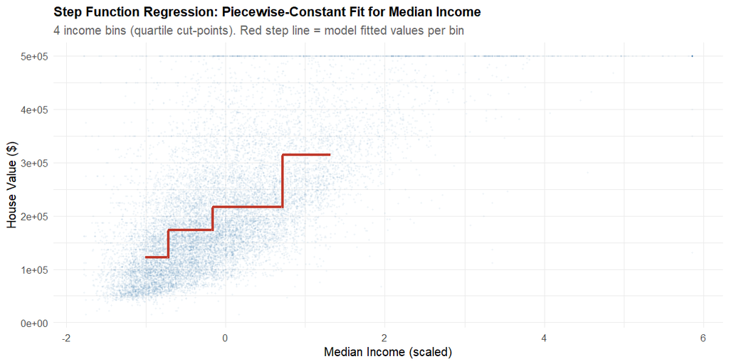

```r
# Visualise step fit for median income
step_income_df <- train_step %>%
  group_by(income_step) %>%
  summarise(
    mean_income  = mean(median_income),
    mean_value   = mean(median_house_value),
    fitted_value = mean(fitted(step_model)[cur_group_rows()])
  )

ggplot(train_step, aes(x = median_income, y = median_house_value)) +
  geom_point(alpha = 0.05, color = "#2e6da4", size = 0.5) +
  geom_step(data = step_income_df, aes(x = mean_income, y = fitted_value),
            color = "#c0392b", linewidth = 1.3, direction = "mid") +
  labs(
    title    = "Step Function Regression: Piecewise-Constant Fit for Median Income",
    subtitle = "4 income bins (quartile cut-points). Red step line = model fitted values per bin",
    x = "Median Income (scaled)", y = "House Value ($)"
  )
```

```r
step_pred <- predict(step_model, newdata = test_step)

all_preds[["StepFunction"]] <- step_pred
all_metrics[["StepFunction"]] <- calc_metrics(y_test, step_pred, "3. Step Function")

cat("Step Function — RMSE:", all_metrics$StepFunction$RMSE,
    "| R²:", all_metrics$StepFunction$R2, "\n")
```

```
Step Function — RMSE: 83018.9 | R²: 0.4998
```

- **Interpretation:** Step functions are easy to interpret — each coefficient represents the average house value increment in that bin relative to the reference. However, the discontinuities at knot boundaries are unrealistic; house prices do not jump discretely. Splines address this by enforcing continuity.

# 9 Model 4 — Regression Splines (B-splines & Natural Splines)

**Theoretical basis** Regression splines fit piecewise polynomials with continuity constraints at knots:

$$y_i = \beta_0 + \sum_{j=1}^{K+3} \beta_j
b_j(x_i) + \varepsilon_i$$

A **cubic B-spline** with $K$ knots has $K + 4$ degrees of freedom. A **natural spline** adds boundary linearity constraints, reducing instability at the tails.

```r
# B-spline model
bspline_model <- lm(
  median_house_value ~
    bs(median_income,            df = 6) +   # 6 df ≈ 3 interior knots
    bs(latitude,                 df = 8) +   # 8 df — bimodal, needs flexibility
    bs(longitude,                df = 8) +
    bs(housing_median_age,       df = 4) +
    bs(rooms_per_household,      df = 4) +
    bs(population_per_household, df = 4) +
    bedrooms_per_room,
  data = train_sc
)

bspline_pred <- predict(bspline_model, newdata = test_sc)

# Natural spline model
nspline_model <- lm(
  median_house_value ~
    ns(median_income,            df = 6) +
    ns(latitude,                 df = 8) +
    ns(longitude,                df = 8) +
    ns(housing_median_age,       df = 4) +
    ns(rooms_per_household,      df = 4) +
    ns(population_per_household, df = 4) +
    bedrooms_per_room,
  data = train_sc
)

nspline_pred <- predict(nspline_model, newdata = test_sc)

cat("B-Spline       — RMSE:", round(rmse(y_test, bspline_pred), 2),
    "| R²:", round(cor(y_test, bspline_pred)^2, 4), "\n")
```

```
B-Spline       — RMSE: 65394.03 | R²: 0.6896
```

```r
cat("Natural Spline — RMSE:", round(rmse(y_test, nspline_pred), 2),
    "| R²:", round(cor(y_test, nspline_pred)^2, 4), "\n")
```

```
Natural Spline — RMSE: 61964.24 | R²: 0.7213
```

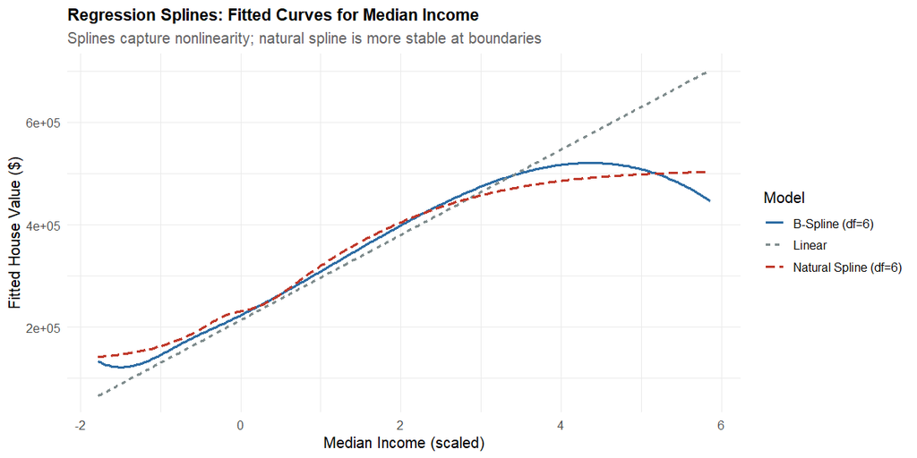

```r
# Compare linear, B-spline, natural spline fits for median_income
grid_df <- data.frame(
  median_income            = seq(min(train_sc$median_income), max(train_sc$median_income), length = 300),
  latitude                 = median(train_sc$latitude),
  longitude                = median(train_sc$longitude),
  housing_median_age       = median(train_sc$housing_median_age),
  rooms_per_household      = median(train_sc$rooms_per_household),
  bedrooms_per_room        = median(train_sc$bedrooms_per_room),
  population_per_household = median(train_sc$population_per_household)

)

grid_df$lm_fit       <- predict(lm_model,      newdata = grid_df %>% mutate(households = median(train_sc$households)))
grid_df$bs_fit       <- predict(bspline_model,  newdata = grid_df)
grid_df$ns_fit       <- predict(nspline_model,  newdata = grid_df)

grid_long <- grid_df %>%
  pivot_longer(c(lm_fit, bs_fit, ns_fit), names_to = "model", values_to = "fitted") %>%
  mutate(model = recode(model,
    lm_fit = "Linear", bs_fit = "B-Spline (df=6)", ns_fit = "Natural Spline (df=6)"))

ggplot(grid_long, aes(x = median_income, y = fitted, color = model, linetype = model)) +
  geom_line(linewidth = 1.1) +
  scale_color_manual(values = c("Linear" = "#7f8c8d",
                                "B-Spline (df=6)" = "#2e6da4",
                                "Natural Spline (df=6)" = "#c0392b")) +
  labs(
    title    = "Regression Splines: Fitted Curves for Median Income",
    subtitle = "Splines capture nonlinearity; natural spline is more stable at boundaries",
    x = "Median Income (scaled)", y = "Fitted House Value ($)",
    color = "Model", linetype = "Model"
  )
```

```r
all_preds[["BSpline"]]       <- bspline_pred
all_preds[["NaturalSpline"]] <- nspline_pred

all_metrics[["BSpline"]]       <- calc_metrics(y_test, bspline_pred, "4a. B-Spline Regression")
all_metrics[["NaturalSpline"]] <- calc_metrics(y_test, nspline_pred, "4b. Natural Spline Regression")
```

- **Interpretation:** Both spline models substantially outperform the linear baseline and the step function. The natural spline is preferred in practice because it imposes linearity at the boundaries, avoiding erratic tail behaviour.

# 10 Model 5 — Smoothing Spline (via GAM `s()`)

**Theoretical basis** Smoothing splines minimise the penalised RSS:

$$\sum_{i=1}^{n}(y_i - g(x_i))^2 + \lambda
\int g''(t)^2 \, dt$$

The tuning parameter $\lambda$ controls the bias-variance trade-off. Large $\lambda$ → smooth $g$; $\lambda \to 0$ → interpolates the data. $\lambda$ is selected automatically via **REML** cross-validation when using `mgcv::gam()`.

```r
# Single-predictor smoothing spline for median_income (illustrative)
ss_model_1d <- mgcv::gam(
  median_house_value ~ s(median_income, k = 10, bs = "cr"),  # cubic regression spline
  data   = train_sc,
  method = "REML"
)

summary(ss_model_1d)
```

```
Family: gaussian
Link function: identity

Formula:
median_house_value ~ s(median_income, k = 10, bs = "cr")

Parametric coefficients:
            Estimate Std. Error t value Pr(>|t|)
(Intercept) 206427.6      639.3   322.9   <2e-16 ***
---
Signif. codes:  0 ‘***’ 0.001 ‘**’ 0.01 ‘*’ 0.05 ‘.’ 0.1 ‘ ’ 1

Approximate significance of smooth terms:
                   edf Ref.df    F p-value
s(median_income) 8.112  8.726 1809  <2e-16 ***
---
Signif. codes:  0 ‘***’ 0.001 ‘**’ 0.01 ‘*’ 0.05 ‘.’ 0.1 ‘ ’ 1

R-sq.(adj) =  0.489   Deviance explained = 48.9%
-REML = 2.1029e+05  Scale est. = 6.7482e+09  n = 16513
```

```r
cat("\nEffective df (median_income smooth):",
    round(sum(ss_model_1d$edf), 2), "\n")
```

```
Effective df (median_income smooth): 9.11
```

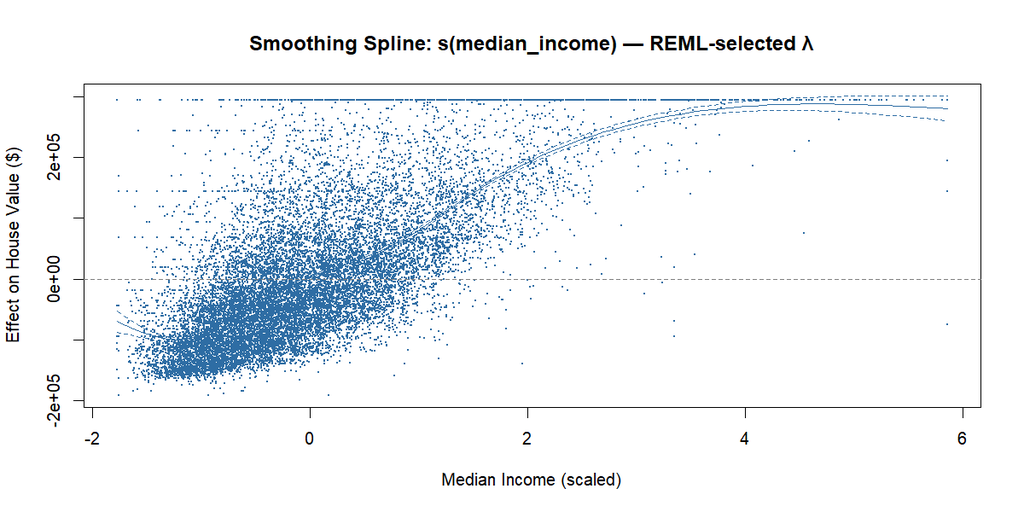

```r
# Plot the smoothing spline with uncertainty band
plot(ss_model_1d, shade = TRUE, col = "#2e6da4", shade.col = "lightblue",
     seWithMean = TRUE, residuals = TRUE, pch = 20, cex = 0.1,
     main = "Smoothing Spline: s(median_income) — REML-selected λ",
     xlab = "Median Income (scaled)", ylab = "Effect on House Value ($)")
abline(h = 0, lty = 2, col = "grey50")
```

```r
# Multi-predictor smoothing spline model
ss_multi <- mgcv::gam(
  median_house_value ~
    s(median_income,            k = 10, bs = "cr") +
    s(latitude,                 k = 12, bs = "cr") +
    s(longitude,                k = 12, bs = "cr") +
    s(housing_median_age,       k =  8, bs = "cr") +
    s(rooms_per_household,      k =  8, bs = "cr") +
    s(population_per_household, k =  8, bs = "cr") +
    bedrooms_per_room,
  data   = train_sc,
  method = "REML"
)

ss_pred <- predict(ss_multi, newdata = test_sc)

all_preds[["SmoothingSpline"]] <- ss_pred
all_metrics[["SmoothingSpline"]] <- calc_metrics(y_test, ss_pred, "5. Smoothing Spline (REML)")

cat("Smoothing Spline — RMSE:", all_metrics$SmoothingSpline$RMSE,
    "| R²:", all_metrics$SmoothingSpline$R2, "\n")
```

```
Smoothing Spline — RMSE: 61351.49 | R²: 0.7268
```

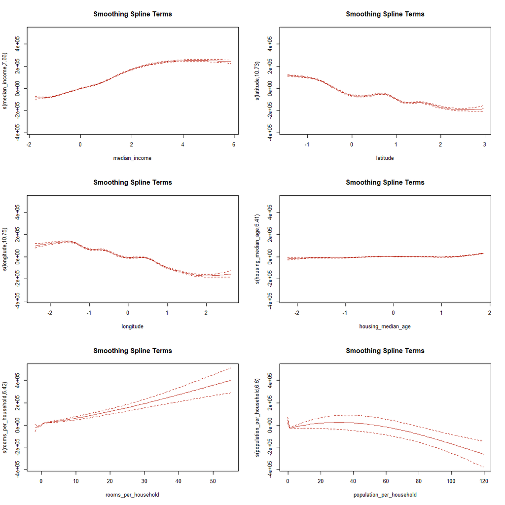

```r
par(mfrow = c(3, 2))
plot(ss_multi, pages = 0, shade = TRUE, col = "#c0392b",
     shade.col = "#f5c6c6", seWithMean = TRUE,
     main = "Smoothing Spline Terms")
par(mfrow = c(1, 1))
```